Climate Change Analysis Report Catalina Mas Pohmajevic and Yaming Dong January, 24, 2021

# Class Exercise 1

As part of our Class Exercise 1, we developed our research question and Hypothesis as follows:

# Research Question

Are people from Northern European countries more in favor of policies to reduce climate change than people from Sourthern European countries?

# Hypothesis

In Northern European countries, individuals are more worried about climate change than in Southern European Countries. For this reason, we hypothesize that the people from Northern European countries would be more in favour the policies to reduce climate change by subsidising renewable energy than people from Southern European countries.

To start with out research, we decided to use the European Social Survey as a source and check the variable “sbsrnen” that answers to the question “To what extent are you in favour or against the following policies in [country] to reduce climate change?”. Firstly we imported the data and then we deleted all missing values while checking there were no answers corresponding to “Refusal”, “Don’t Know” or “No Answer”.

```r
setwd("/Users/catalinamasp/Documents/UNIMI/R")
ess <- import("ESS8e02.2_F1.sav")
ess_pg <- ess[, c("sbsrnen","cntry")]
ess_pg2 <- na.omit(ess_pg)
view(ess_pg2)
```

Afterwards, we renamed the name of the variable, calling it “Subsidise Renewable Energy”. Then, we decided to recode the variable in order to group the different values into categories, therefore we set the category “Favor” for the values 1 “Strongly in favour” and 2 “Somewhat in favour”. Then, for the value 3 “Neither in favour nor against”, we set the category “Neutral” while for 4, and 5 “Somewhat against” and “Strongly against”, respectively, we set the category “Against”.

```r
  names(ess_pg2)[names(ess_pg2) == "sbsrnen"] <- "SubsidiseRenewableEnergy"
ess_pg2 <-ess_pg2 %>%
  mutate(recoded_opinion = ifelse(SubsidiseRenewableEnergy <= 2, "Favor",
                                  ifelse(SubsidiseRenewableEnergy == 3, "Neutral",
                                          "Against")))
```

To start with our analysis we had to filter the data selecting just the countries we were interested in. Therefore, we grouped Sweden, Finland, Norway and Iceland under Northern European Countries and Portugal, Spain and Italy under “Southern European Countries” as categories under the new variable “Region”.

```r
ess_pg2 <- ess_pg2 %>%
  mutate(region = ifelse(cntry == "ES" | cntry == "PT" | cntry =="IT", "Southern Countries",
  ifelse(cntry == "IS" | cntry == "SE" | cntry == "FI" | cntry == "NO", "Northern Countries",
  "Others" )))

ess_pg2 <- filter(
  ess_pg2,
  region %in% c("Southern Countries", "Northern Countries")
)
```

# Visualization testing

To test our empirical hypothesis we first visualized the data in a ggplot column bar, in order to see which was the recorded opinion per region.

We can see that in Northern European countries, more than 4000 people are in favor to subsidise renewable energy to reduce climate change, whereas in Southern European countries, around 4000 people have a favorable opinion. It shows that the people from Northern European countries would be more in favor the policies to reduce climate change by subsidising renewable energy than people from southern Europea countries. Furthermore, we can see that in Southern European Countries there are more people against subsidising the renewable energy to reduce climate change than people that are neutral about the topic, where in Northern European Countries is the other way around.

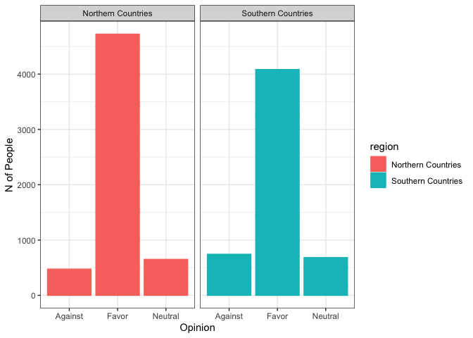

# Statistical test

To test the relationship between how worried people in these countries are about Climate Change and their opinion on subsidising renewable energies to reduce it, we picked another variable called “wrclmch” that we recoded into “Worried about climate change”.

```r
ess <- ess%>%
    mutate(region = ifelse(cntry == "ES" | cntry == "PT" | cntry =="IT", "Southern Countries",
                      ifelse(cntry == "IS" | cntry == "SE" | cntry == "FI" | cntry == "NO", "Northern Countries",
                                "Others" )))

ess_pg3 <- ess[, c("sbsrnen","region","wrclmch")]
ess_pg3 <- na.omit(ess_pg3)
names(ess_pg3)[names(ess_pg3) == "sbsrnen"] <- "SubsidiseRenewableEnergy"
names(ess_pg3)[names(ess_pg3) == "wrclmch"] <- "WorriedClimateChange"

ess_pg3 <- filter(
    ess_pg3,
    region %in% c("Southern Countries", "Northern Countries")
)
```

To test the relationship we developed a linear regression where the Subsidise Renewable Energy variable is the dependent variable and “Worried Climate Change” is the independent variable.

```r
L.Regression <- lm(SubsidiseRenewableEnergy ~ WorriedClimateChange,
      data = ess_pg3)
summary(L.Regression)
```

```
##
## Call:
## lm(formula = SubsidiseRenewableEnergy ~ WorriedClimateChange,
##     data = ess_pg3)
##
## Residuals:
##     Min      1Q  Median      3Q     Max
## -1.3944 -0.8581 -0.0369  0.1419  3.3207
##
## Coefficients:
##                      Estimate Std. Error t value Pr(>|t|)
## (Intercept)           2.57320    0.03655   70.41   <2e-16 ***
## WorriedClimateChange -0.17878    0.01108  -16.13   <2e-16 ***
## ---
## Signif. codes:  0 '***' 0.001 '**' 0.01 '*' 0.05 '.' 0.1 ' ' 1
##
## Residual standard error: 1.028 on 11203 degrees of freedom
## Multiple R-squared:  0.0227, Adjusted R-squared:  0.02261
## F-statistic: 260.2 on 1 and 11203 DF,  p-value: < 2.2e-16
```

Then, we plotted the regression.

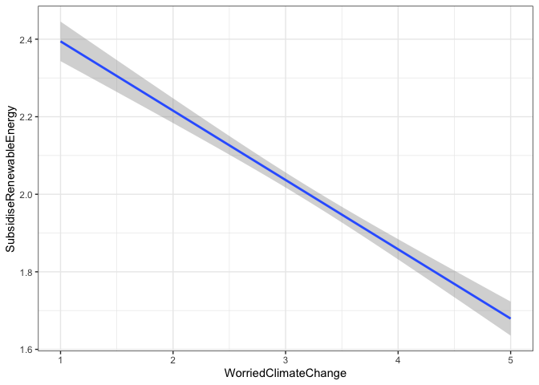

```r
ggplot(ess_pg3, (aes(x = WorriedClimateChange, y = SubsidiseRenewableEnergy))) +
    geom_smooth(method = "lm") +
    theme_bw()
```

We can see the “WorriedClimateChange” have a negative effect on “SubsidiseRenewableEnergy”, it means the larger “WorriedClimateChange”, the smaller “SubsidiseRenewableEnergy”. It represents the more people worried about climate change, they would be more in favor of policies to reduce climate change.

# Conclusion

So, we can conclude that the people from Northern European countries would be more in favour the policies to reduce climate change by subsidising renewable energy than people from Southern European countries.And the more people worried about climate change, they would be more in favor of policies to reduce climate change.